# S7 : Developing Ecological Niche Models

Marine Ecological Modelling  
Global Climate Change

#### S7 : Developing Ecological Niche Models

author: Jorge Assis  
contact: jmassis@ualg.pt  
code: github.com/jorgeassis  
tweets: twitter.com/jorgemfassis  
journal: [medium.com/theMarineDataScientist](https://medium.com/themarinedatascientist)

##### Model fitting [!]

Model fitting is the heart of any SDM application. Many different algorithms are available to fit the relationship between occurrence records and environmental predictors.

```r
# always set a working directory
setwd(".")

# all packages needed and functions in external source file
source("sourceFunctions.R")
```

###### Generalised linear models

Generalised linear model (GLM) is a typical parametric regression algorithm that can fit linear, quadratic or higher polynomial terms (check poly()) and interactions between predictors.

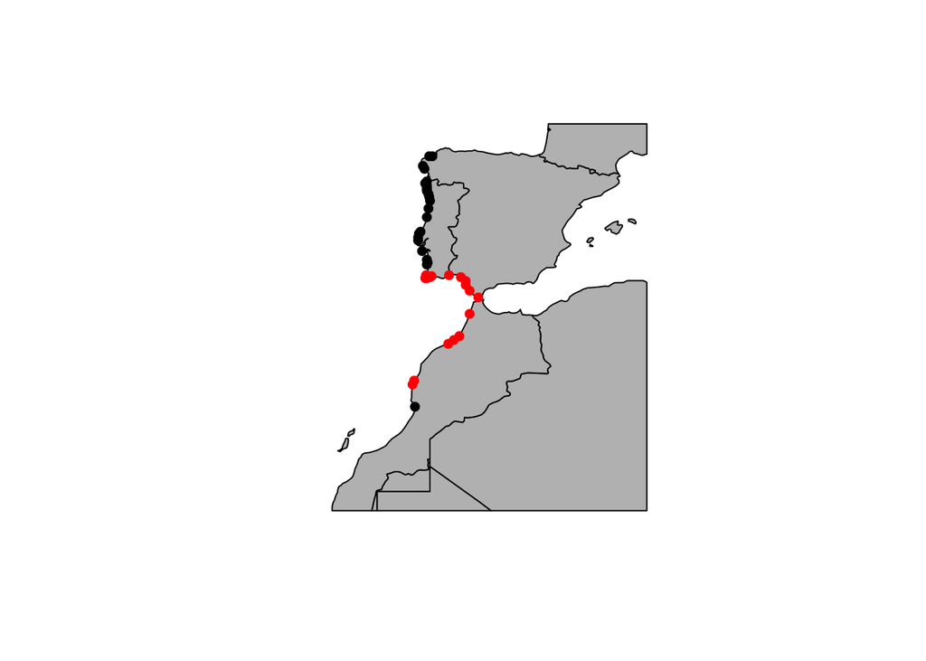

```r
world <- ne_countries(scale = 'medium')

# load a presence / absence dataset for an intertidal species
records <- read.csv("Data/dataBases/Kelp-monitoring.csv")
presences <- records[records[,"PA"] == 1 , c("Lon","Lat") ]
absences <- records[records[,"PA"] == 0 , c("Lon","Lat") ]

# crop landmass to the European extent
IberianExtent <- extent(-15, 5, 25, 45)
iberianLandMass <- crop(world,IberianExtent)

# plot presence / absence records
plot(iberianLandMass , col="gray")
points( records[ records[,"PA"] == 1,c("Lon","Lat")] , col="Black" , pch=16 )
points( records[ records[,"PA"] == 0,c("Lon","Lat")] , col="Red" , pch=16 )
```

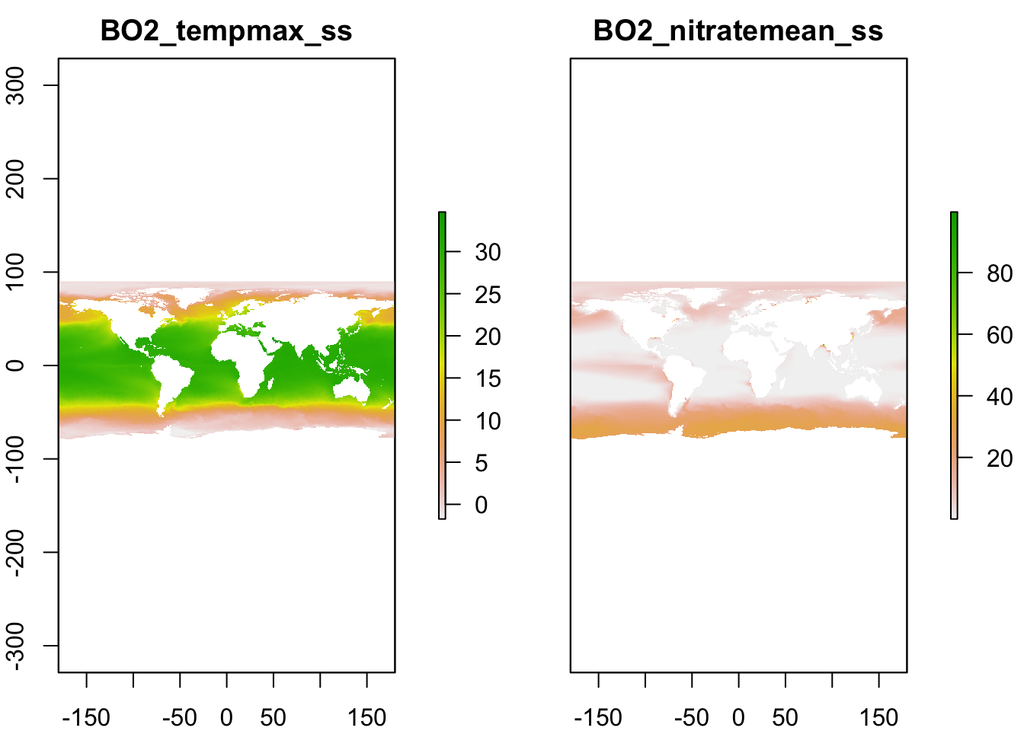

```r
# load layers of sea surface temperatures and nutrients
environmentalConditions <- load_layers(c("BO2_tempmax_ss", "BO2_nitratemean_ss"))
plot(environmentalConditions)
```

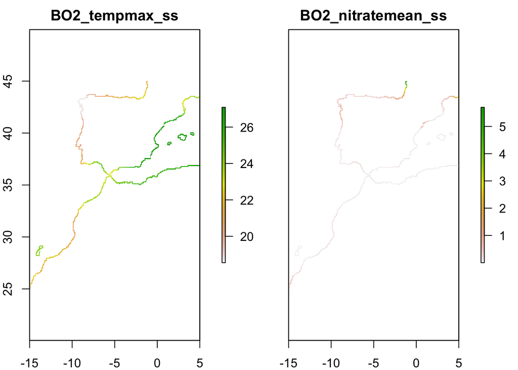

```r
# crop layers to the coastline region to match intertidal distributions
coastline <- raster("Data/rasterLayers/CoastLine.tif")
environmentalConditions <- mask(environmentalConditions,coastline)

# crop layers to the Iberian Peninsula
IberianExtent <- extent(-15, 5, 25, 45)
environmentalConditions <- crop(environmentalConditions,IberianExtent)
plot(environmentalConditions)
```

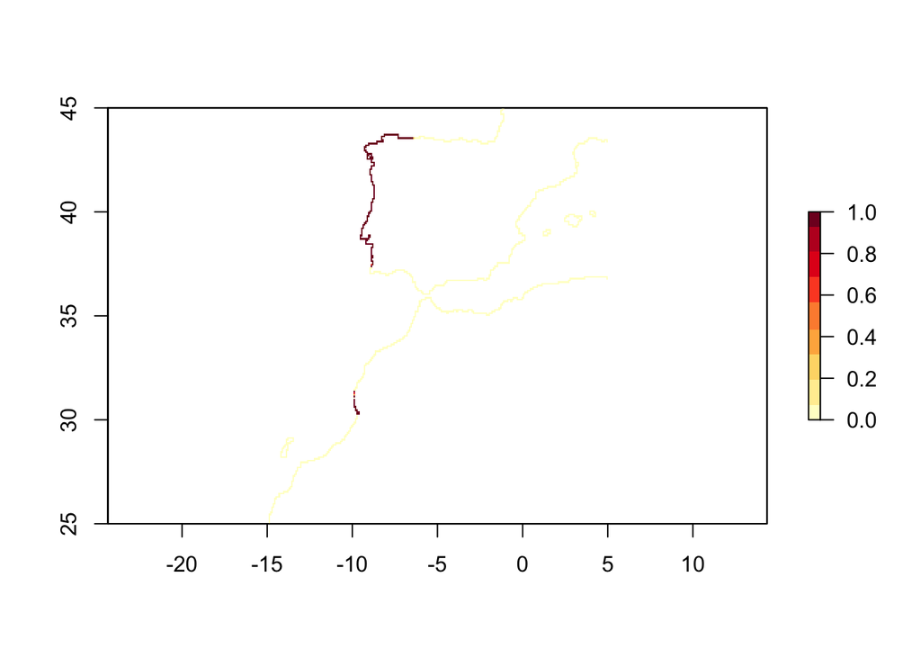

```r
# extract environmental values and make an object with all information to model
modelData <- prepareModelData(presences,absences,environmentalConditions)

# fit a binomial GLM to the dataset
model <- trainGLM(modelData)

# predict the distribution with the GLM over a raster stack
map <- predict(environmentalConditions,model,type='response')

# plot response of model
plot(map , col = brewer.pal(n = 11, name = "YlOrRd") )
```

###### Pseudo-absence data

If true absence data is not available, but one wants to fit an ecological niche model model, pseudo-absence data can be generated. The optimum settings to generate pseudo-absence data can be inferred from Barbet-Massin et al. (2012), which compared the performance of a variety of algorithms with different combinations of number of pseudo-absence and generation method settings.

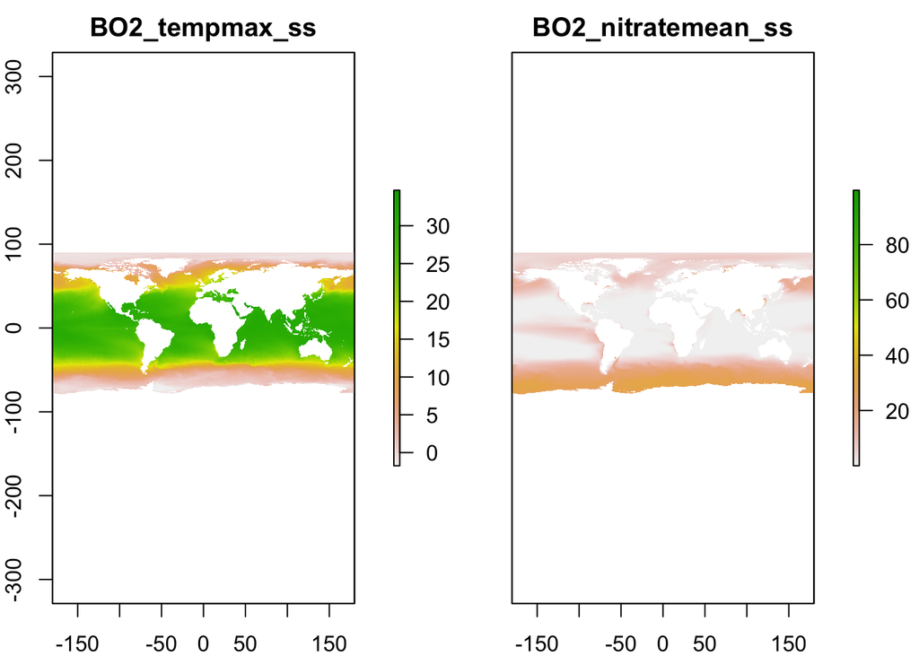

```r
# load a presence dataset for an intertidal species
records <- read.csv("Data/dataBases/Kelp-monitoring.csv")
presences <- records[records[,"PA"] == 1 , c("Lon","Lat") ]

# crop landmass to the European extent
iberianExtent <- extent(-15, 5, 25, 45)
iberianLandMass <- crop(world,iberianExtent)

# load layers of sea surface temperatures and nutrients
environmentalConditions <- load_layers(c("BO2_tempmax_ss", "BO2_nitratemean_ss"))
plot(environmentalConditions)
```

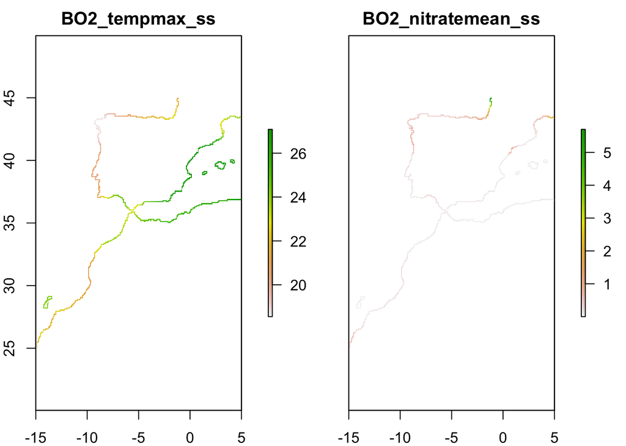

```r
# crop layers to the coastline region to match intertidal distributions
coastline <- raster("Data/rasterLayers/CoastLine.tif")
environmentalConditions <- mask(environmentalConditions,coastline)

# crop layers to the Iberian Peninsula
iberianExtent <- extent(-15, 5, 25, 45)
environmentalConditions <- crop(environmentalConditions,iberianExtent)
plot(environmentalConditions)
```

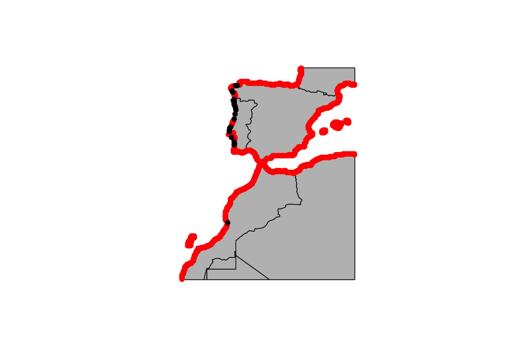

```r
# generate pseudo-absences
absences <- pseudoAbsences(environmentalConditions,presences,n=10000)

# plot presence and pseudo-absences records
plot(iberianLandMass , col="gray")
points(absences,col="Red",pch=16)
points(presences,col="Black",pch=16)
```

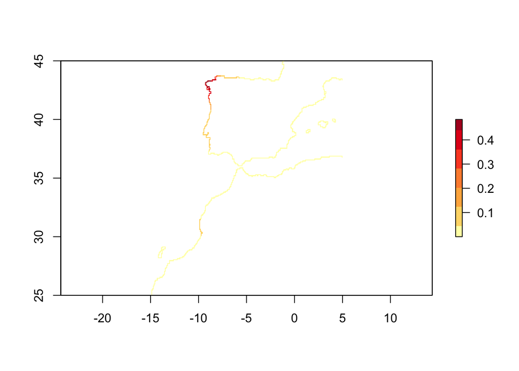

```r
# extract environmental values and make an object with all information to model
modelData <- prepareModelData(presences,absences,environmentalConditions)

# fit a binomial GLM to the dataset
model <- trainGLM(modelData)

# predict the distribution with the GLM over a raster stack
map <- predict(environmentalConditions,model,type='response')

# plot glm and records
plot(map , col = brewer.pal(n = 7, name = "YlOrRd") )
```

###### Maximum Entropy

Maxent only uses presence data and the algorithm compares the locations of where a species has been found to all the environments that are available in the study region. It defines these available environments by sampling a large number of points throughout the study area, which are referred to as background points. Because background points can include locations where the species is known to occur, background points are not the same as pseudo-absence points. Background points define the available environment.

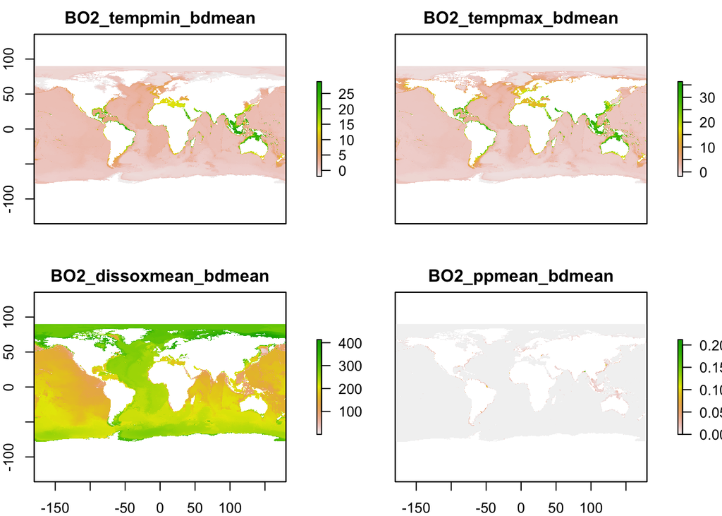

```r
# load a presence dataset for a deep coral
presences <- read.csv("Data/dataBases/Paramuricea_clavata.csv",sep=";")
presences <- presences[,c("Lon","Lat")]

# load layers of sea surface temperatures and nutrients
environmentalConditions <- load_layers(c("BO2_tempmin_bdmean","BO2_tempmax_bdmean","BO2_dissoxmean_bdmean","BO2_ppmean_bdmean"))
plot(environmentalConditions)
```

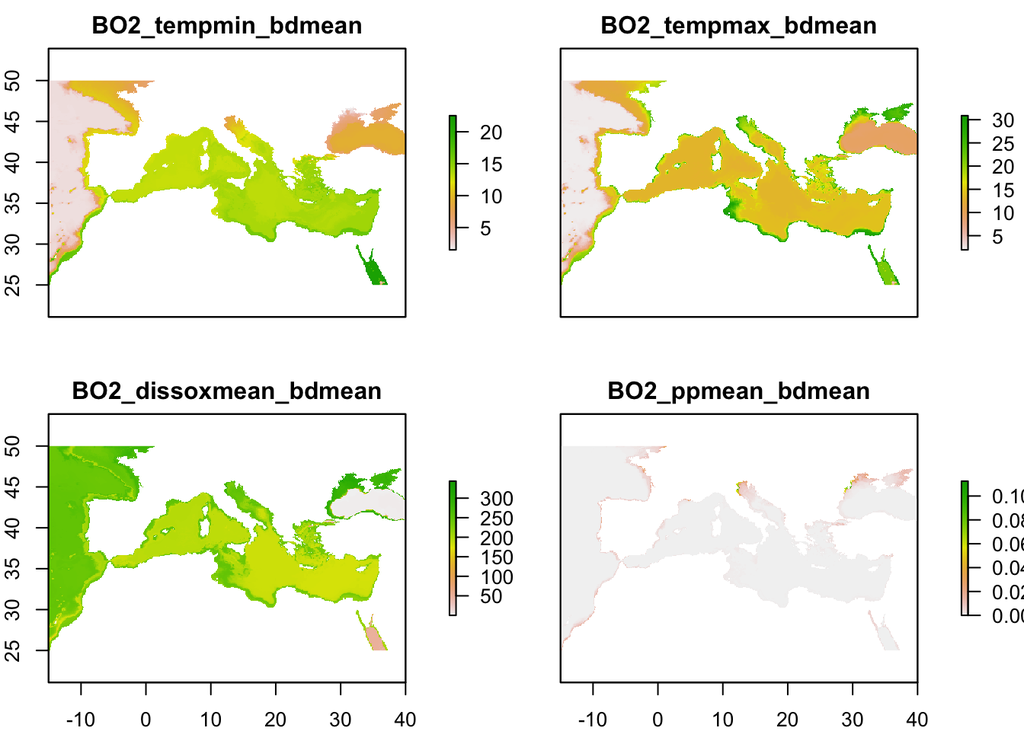

```r
# crop layers to the European extent
europeanExtent <- extent(-15, 40, 25, 50)
environmentalConditions <- crop(environmentalConditions,europeanExtent)
plot(environmentalConditions)
```

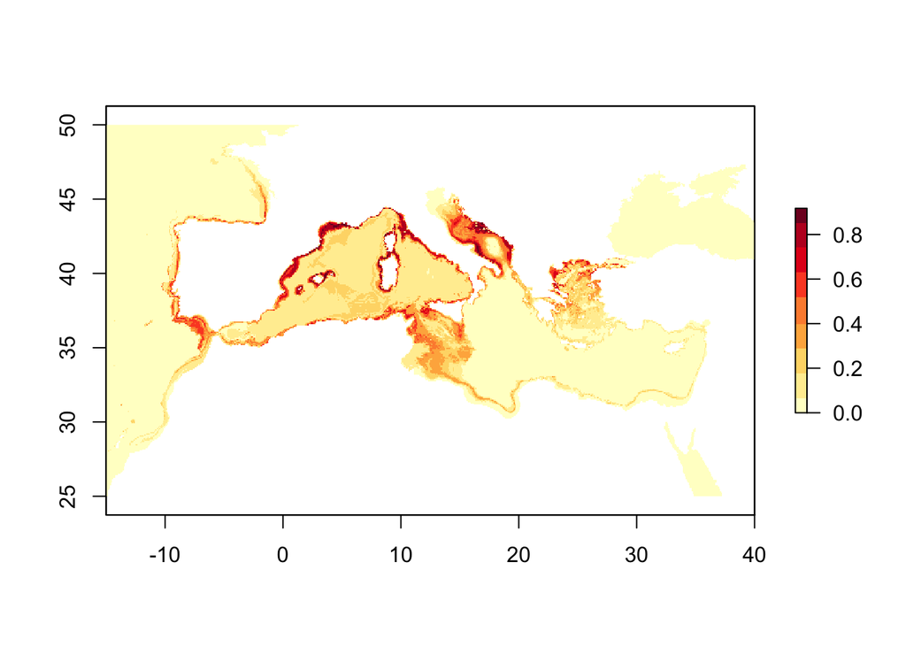

```r
# generate pseudo-absences
background <- backgroundInformation(environmentalConditions,n=10000)

# extract environmental values and make a data.frame with PA information
modelData <- prepareModelData(presences,background,environmentalConditions)

# fit a Maxent model to the dataset
model <- train("Maxnet", modelData, folds = NULL )

# predict with Maxent to raster stack
map <- predict(model, environmentalConditions, type="logistic")
plot(map, col = brewer.pal(n = 11, name = "YlOrRd") )
```

###### Challenge 7.1

The main objetive of this challenge is to **fit** a MaxEnt model to your own occurrence and environmental data.

```r
# packages, data and functions needed to accomplish the challenge
source("sourceFunctions.R")

list_layers(datasets = "Bio-ORACLE")
View()
load_layers()
crop()
backgroundInformation()
prepareSWD()
train()
predict()
plot()
```

##### Model transferability [!]

Model transferability is the process of transferring a model to a new dataset (e.g., different climate conditions or different geographic region).

###### Temporal transferability

```r
# load a presence dataset for deep coral
presences <- read.csv("Data/dataBases/Paramuricea_clavata.csv",sep=";")
presences <- presences[,c("Lon","Lat")]

# load layers of sea surface temperatures
environmentalConditionsPresent <- load_layers(c("BO2_tempmin_bdmean","BO2_tempmax_bdmean"))
environmentalConditionsRCP26 <- load_layers(c("BO2_RCP26_2100_tempmin_bdmean","BO2_RCP26_2100_tempmax_bdmean"))

# compare layer names
names(environmentalConditionsPresent)
```

```
## [1] "BO2_tempmin_bdmean" "BO2_tempmax_bdmean"
```

```r
names(environmentalConditionsRCP26)
```

```
## [1] "BO2_RCP26_2100_tempmin_bdmean" "BO2_RCP26_2100_tempmax_bdmean"
```

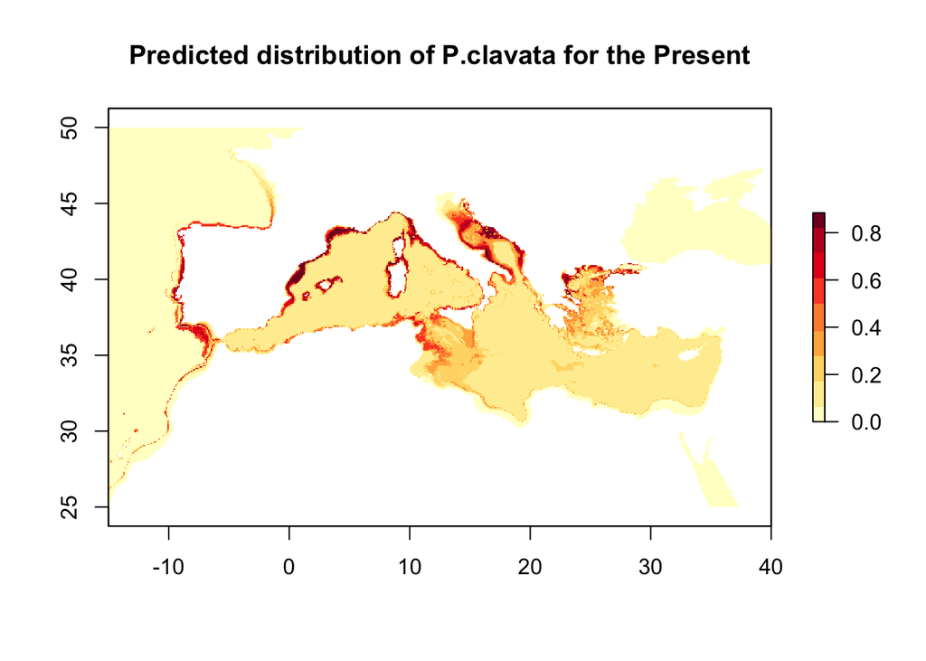

```r
# change layer names for them to match
names(environmentalConditionsRCP26) <- c("BO2_tempmin_bdmean","BO2_tempmax_bdmean")

# crop layers to the European extent
europeanExtent <- extent(-15, 40, 25, 50)
environmentalConditionsPresent <- crop(environmentalConditionsPresent,europeanExtent)
environmentalConditionsRCP26 <- crop(environmentalConditionsRCP26,europeanExtent)

# generate background information
background <- backgroundInformation(environmentalConditionsPresent,n=10000)

# extract environmental values and make a data.frame with PA information
modelData <- prepareModelData(presences,background,environmentalConditionsPresent)

# fit a Maxent model to the dataset
model <- train("Maxnet", modelData, folds = NULL )

# predict with Maxent to raster stack
map <- predict(model, environmentalConditionsPresent, type=c("logistic"))
plot(map, main="Predicted distribution of P.clavata for the Present" , col = brewer.pal(n = 11, name = "YlOrRd") )
```

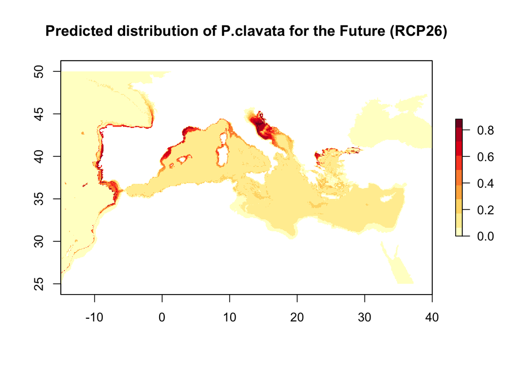

```r
mapRCP26 <- predict(model, environmentalConditionsRCP26, type=c("logistic"))
plot(mapRCP26, main="Predicted distribution of P.clavata for the Future (RCP26)" , col = brewer.pal(n = 11, name = "YlOrRd") )
```

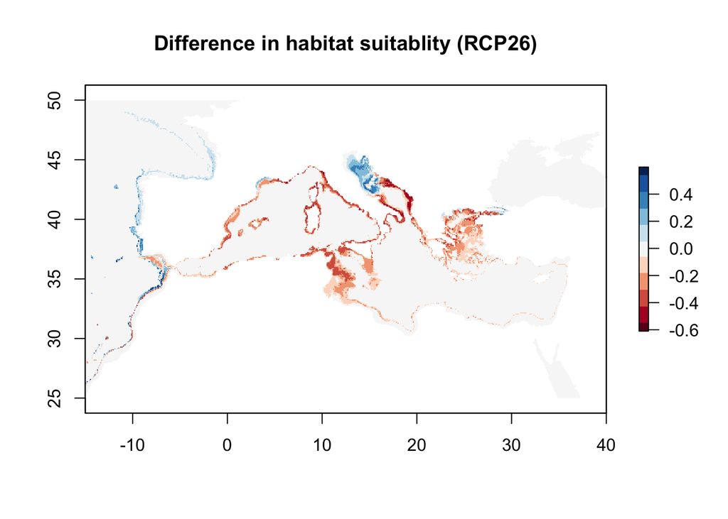

```r
differenceRCP26 <- mapRCP26 - map
plot(differenceRCP26, main="Difference in habitat suitablity (RCP26)" , col = brewer.pal(n = 11, name = "RdBu") )
```

###### Challenge 7.2

The main objetive of this challenge is to **fit** a MaxEnt model to your own occurrence and environmental data and transfer the model to different climate conditions.

```r
# packages, data and functions needed to accomplish the challenge
source("sourceFunctions.R")

list_layers(datasets = "Bio-ORACLE")
list_layers_future(datasets = "Bio-ORACLE")
View()
load_layers()
crop()
backgroundInformation()
prepareSWD()
train()
predict()
plot()
```

###### Spatial transferability

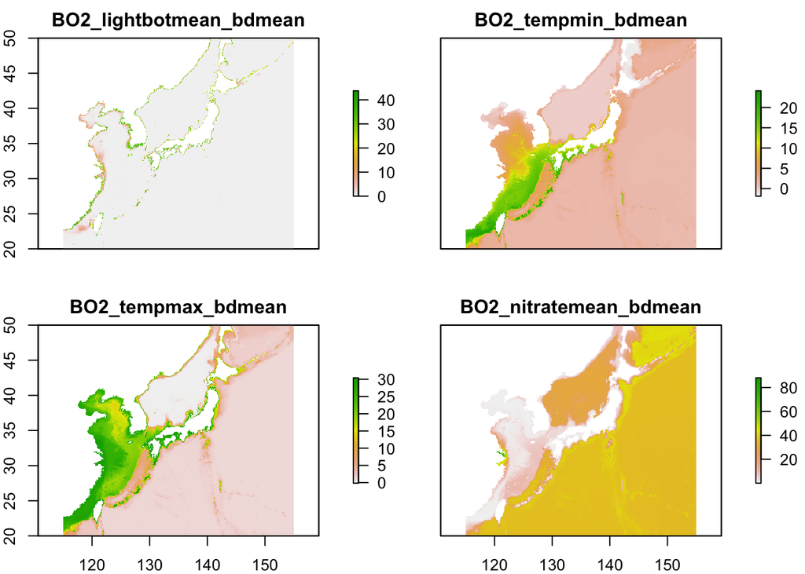

```r
# load a presence dataset for an invasive species
presences <- getOccurrencesGBIF("Undaria pinnatifida")
presences <- presences[,c("Lon","Lat")]

# load layers of light, sea surface temperatures and nutrients
environmentalConditions <- load_layers(c("BO2_lightbotmean_bdmean","BO2_tempmin_bdmean","BO2_tempmax_bdmean","BO2_nitratemean_bdmean"))

# crop layers to the native extent
nativeExtent <- extent(115, 155, 20 , 50)
environmentalConditionsNative <- crop(environmentalConditions,nativeExtent)
plot(environmentalConditionsNative)
```

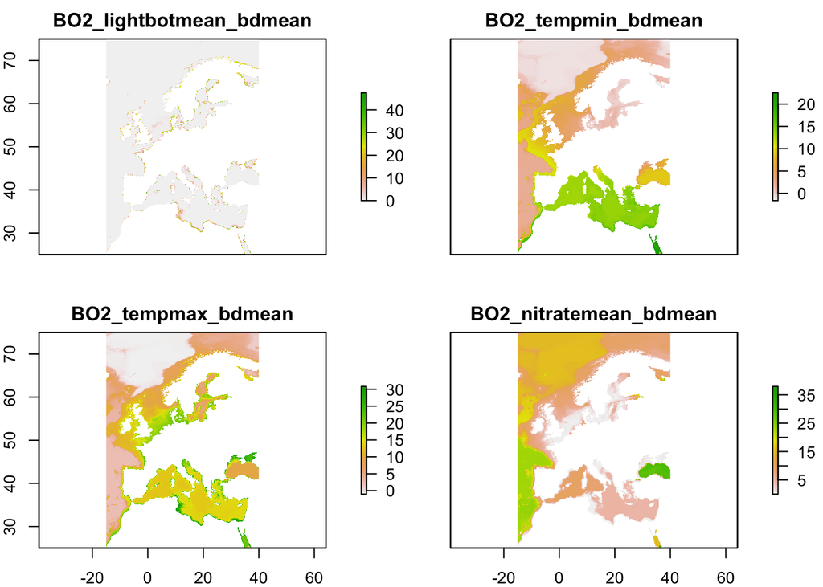

```r
# crop layers to the European extent
europeanExtent <- extent(-15, 40, 25, 75)
environmentalConditionsEurope <- crop(environmentalConditions,europeanExtent)
plot(environmentalConditionsEurope)
```

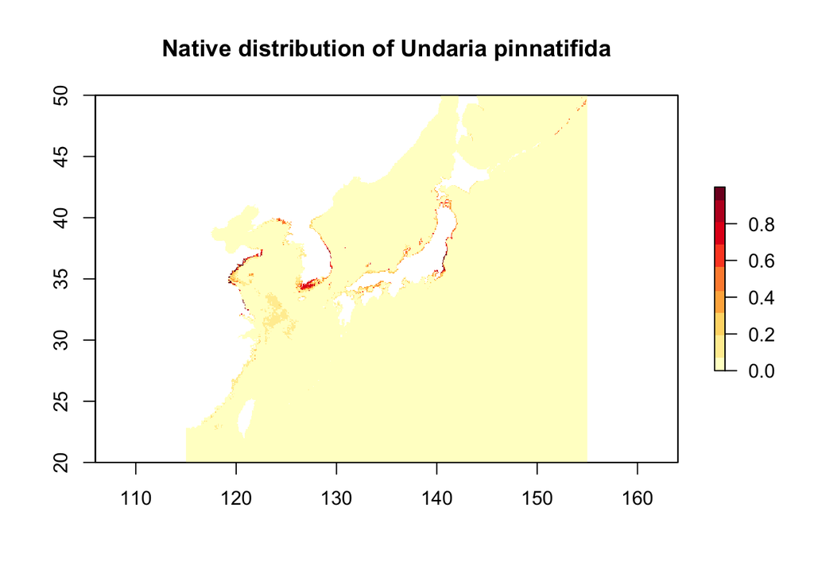

```r
# generate pseudo-absences
background <- backgroundInformation(environmentalConditionsNative,n=10000)

# extract environmental values and make a data.frame with PA information
modelData <- prepareModelData(presences,background,environmentalConditionsNative)
# fit a Maxent model to the dataset
model <- train("Maxnet", modelData, folds = NULL )

# predict with Maxent to raster stack
mapNative <- predict(model, environmentalConditionsNative, type=c("logistic"))
plot(mapNative, main="Native distribution of Undaria pinnatifida" , col = brewer.pal(n = 11, name = "YlOrRd") )
```

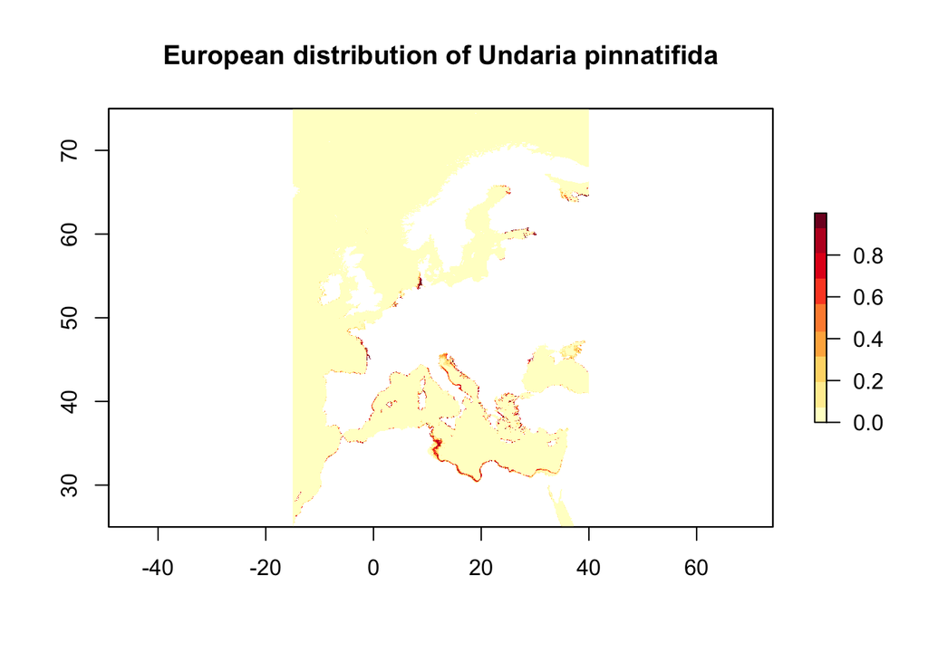

```r
mapEurope <- predict(model, environmentalConditionsEurope, type=c("logistic"))
plot(mapEurope, main="European distribution of Undaria pinnatifida" , col = brewer.pal(n = 11, name = "YlOrRd") )
```

###### Challenge 7.3

The main objetive of this challenge is to **fit** a MaxEnt model to your own occurrence and environmental data and transfer the model to a different geographic regions

```r
# packages, data and functions needed to accomplish the challenge
source("sourceFunctions.R")

# Bio-ORACLE layer:
# Sea water temperature (maximum)

list_layers(datasets = "Bio-ORACLE")
list_layers_future(datasets = "Bio-ORACLE")
View()
load_layers()
plot(object)
```

R Markdown tutorial developed by Jorge Assis under the International License [[CC BY 4.0]](https://creativecommons.org/licenses/by/4.0/). When using, copying or modifying, the attribution citation should be **Assis, J. (2020) Marine Ecological Modelling and Global Climate Change. theMarineDatasSientist**.